# Task 4 - Naples Reef

Lucas Boyd

10/24/2021

## Overview

This document wrangles and visualizes data from the Santa Barbara Long Term Ecological Research Program. This code examines purple urchin sizes at the Naples Reef in 2010 and visualizes the data in a QQplot. Then, the code compares mean urchin size in the annual treatment versus control groups.

## Setup

```r
knitr::opts_chunk$set(echo = TRUE, message = FALSE, warning = FALSE)
options(digits = 3) # changing number of significant figures
# attaching packages
library(tidyverse)
library(here)
library(janitor)
library(lubridate)
library(kableExtra)
```

## Data

**Data Citation:** Reed, D. 2020. SBC LTER: Reef: Long-term experiment: Kelp removal: Urchin size frequency distribution ver 20. Environmental Data Initiative. https://doi.org/10.6073/pasta/5a1e9ef03aa47bd2225c0bb98a02a63b.

**Summary of variables:**

- date: date urchin recorded
- site: site along the SB coast (the five sites can be explored here)
- treatment: indicates experimental kelp treatments:
  - CONTROL = giant kelp left intact
  - ANNUAL = giant kelp is “removed…once each winter and allowed to re-colonize over the course of the year”
- size: urchin diameter (cm), measured to the nearest 0.5 cm
- scientific_name: scientific name
- common_name: species common name (either red or purple urchin)

## Data wrangling

Wrangling data to only include observations of purple urchins at the Naples Reef.

```r
urchins_naples <- read_csv(here("data", "urchins.csv")) %>% # reading in the data
  clean_names() %>% # cleaning up the names
  filter(common_name == "Purple Urchin", # only retain purple urchin observations
         site == "NAPL") %>% # at the naples site
  mutate(date_new = mdy(date)) %>% # converting dates to nice format
  mutate(year = year(date_new)) %>% # adding a column for year
  filter(year == "2010")
```

## Exploratory plots

Exploring faceted histograms and qqplots to visually represent the data.

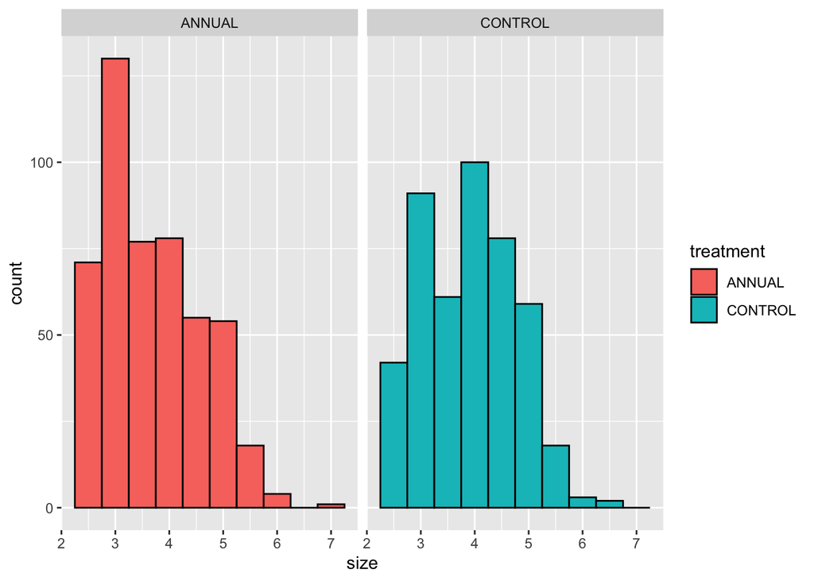

```r
ggplot(data = urchins_naples, aes(x = size, fill = treatment)) + # creating faceted histogram of the data
         geom_histogram(bins = 10, color = "black") +
  facet_wrap(~ treatment)
```

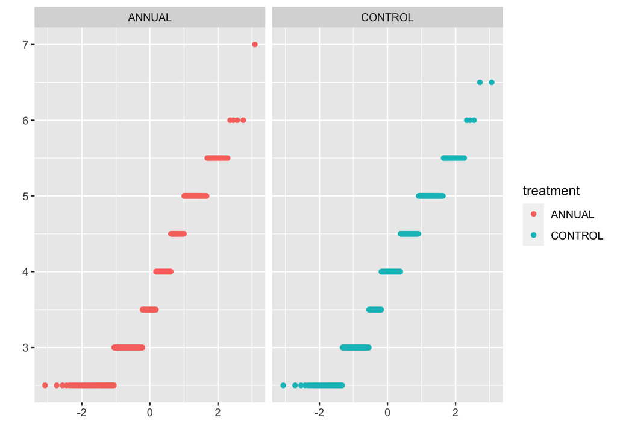

```r
qplot(sample = size, data = urchins_naples, color = treatment) +
  facet_wrap(~ treatment) # making a qqplot to represent the data
```

The control treatment group is more normally distributed, while the annual treatment group is highly concentrated on the lower end of the range of values. This seems to indicate that the annual treatment does have an effect on the size of purple urchins.

## Summarizing data

```r
urchins_naples %>% # starting with urchins_naples
  group_by(treatment) %>% # grouping by treatment
  summarize(mean_size = mean(size), # creating a summary table with mean, SD and sample size
            standard_dev = sd(size),
            sample_size = n()) %>%
  kable(col.names = c("Treatment", # renaming the columns
                      "Mean Diameter (cm)",
                      "Standard Devation (cm)",
                      "Sample Size"),
        caption = "Fig. 1 looks at mean purple urchin diameter (cm) across treatment conditions at Naples Reef in 2010, comparing the annual treatment to the control.") %>% # adding a figure caption
  kable_minimal() %>% # changing the theme
  kable_styling(full_width = FALSE, font = 14) # styling the table
```

Fig. 1 looks at mean purple urchin diameter (cm) across treatment conditions at Naples Reef in 2010, comparing the annual treatment to the control.

| Treatment | Mean Diameter (cm) | Standard Devation (cm) | Sample Size |
| --- | --- | --- | --- |
| ANNUAL | 3.68 | 0.898 | 488 |
| CONTROL | 3.89 | 0.865 | 454 |